# Supplementary NatPoKe Figures March2025

# Introduction

This .html file contains all the additional figures that will compose the Supplementary materials for the NatPoKe article.

# Multi-species abundance over-time

Making use of the .csv file saved as a model output for each species, we will analyze how species populations change over time by combining data from multiple regions.

1. Create a list, `datasets`, that includes the directories to the .csv files containing the total number of individuals (`TNIND`) data for different continents: Europe, North America, Asia, Africa, and South America.
2. Then use `do.call("rbind", datasets)` to merge these datasets into a single dataframe called `TNIND_yr`.
3. Set the two key timepoints: `t_burnin <- 100` marks the end of the burn-in period (a stabilization phase before the actual analysis) and `t_policy <- 110` represents the moment when a specific policy or environmental change occurs, which may impact population trends.
4. Plot Total Number of Individuals Over Time using `ggplot()`

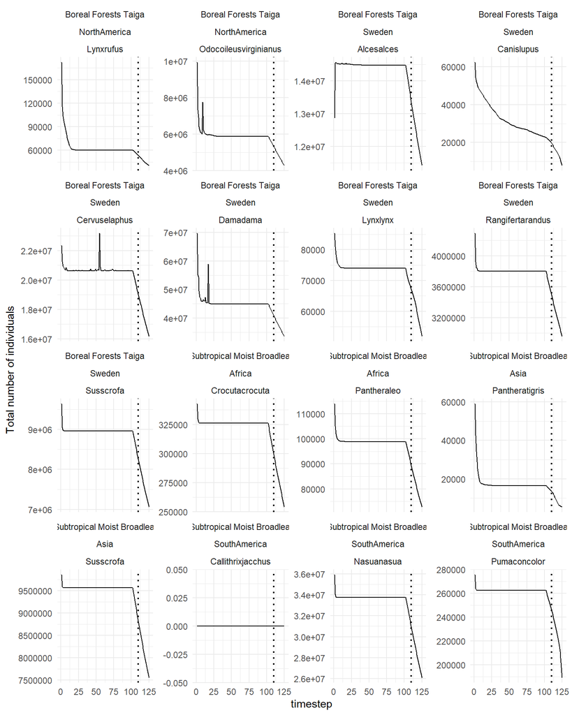

```r
# list directories for all continents output folder
datasets <- list(TNIND_europe, TNIND_northamerica, TNIND_asia, TNIND_africa, TNIND_southamerica)

# bind all df together
TNIND_yr <- do.call("rbind", datasets)

# define key timespoints
t_burnin <- 100
t_policy <- 110

# Custom labeller to show biome name only once per section
custom_labeller <- function(labels) {
  labels$biome <- ifelse(duplicated(labels$biome), "", labels$biome)
  labels
}

TNIND_per_year <- ggplot(data = TNIND_yr, aes(x = timestep, y = TNIND, group = species)) +
  geom_line() +
  facet_wrap(biome+region~ species, scales = "free_y", ncol = 4) +
  labs(y = "Total number of individuals") +
  theme_minimal() +
  geom_vline(xintercept = t_policy, linetype = "dotted", color = "black", size = 0.8)  # add line at time of disturbance

TNIND_per_year
```

# Model Validation

To determine whether the model accurately represents the behavior of the system (Aumann, 2007), we applied model validation analysis as follows:

> This relies on a previously on a user defined function (`validateModel1.2()`) that compares estimated values from our model simulation with an external data source, which in this case came from Santini et al. 2022, providing insights into the model’s accuracy.
1. first, it prepares the independent density data, from Santini et al. 2022, filtering it to match our target species and formatting it accordingly;
2. then it searches the given output directory for .tif files matching the pattern for each target species and the given validation Year (to facilitate debugging, it prints a message saying which raster was used for which species, and warns if some are missing).
3. afterwards, it loads and stacks the rasters and converts the created stack into a dataframe with species as a column, enabling cell-by-cell analysis.
4. since the expected datasets are very large (continental range scale), the function randomly samples 300 abundance values per species from the abundance dataset using `sample()`.
5. subsequently, the function converts predicted abundance to predicted density (individuals per km²), by dividing the abundance values per cell with modelling resolution.
6. finally, the function returns a list containing both the processed independent density estimates and the calculated model-predicted densities, facilitating the comparison and validation of the model’s performance.

> This analysis needs to be done per region, or else errors will appear due to different extent rasters and the same species occurring in more than one region at a time.

> **Suggestion:** Save each model run per biome and region in a different folder feed each one separately to the function. plot each results and then, if it is necessary to visualize all plots together use the [patchwork package](https://patchwork.data-imaginist.com/articles/patchwork.html) to do that.

```r
validateModel1.2 <- function(targetspecies, independentDensity, dirouts, spData, validationYear) {
  # Compares mean density estimated by model per cell with
  # predicted density from independent model extract predicted abundance
  # and join with observed abundance
  # 1. Loads rasters - 2. Sample ~300 random cells per species - 3. Calculate predicted densities - 4. Returns a comparison-ready list

  ## Species density estimates by an INDEPENDENT SOURCE (akin to observed density)
  independentDensity <- independentDensity %>%
    dplyr::filter(Species %in% targetspecies) %>%
    dplyr::select(Species, lw95, lw75, PredMd, up75, up95) %>%
    mutate(
      lw95 = as.numeric(lw95),
      lw75 = as.numeric(lw75),
      PredMd = as.numeric(PredMd), # Predicted population density (individuals/km2)
      up75 = as.numeric(up75),
      up95 = as.numeric(up95)
    ) %>%
    rename(
      species = Species,
      meanDensity = PredMd
    )

  ## Species density estimated by METARANGE from multiple directories
  abundance_files <- list()
  for (target_sps in targetspecies) {
    all_files <- character()
    for (dirout in dirouts) { #Iterate through each directory
      files <- list.files(
        path = dirout,
        pattern = paste0(validationYear, "_", target_sps, "_abundance\\.tif$"),
        full.names = TRUE
      )
      all_files <- c(all_files, files)
    }
    abundance_files[[target_sps]] <- all_files
    if(length(all_files) > 0){
      message(paste("Used rasters for", target_sps, ":", paste(basename(all_files), collapse = ", ")))
    } else {
      warning(paste("No rasters found for", target_sps, "in the given directories."))
    }
  }

  abundance_rasters <- lapply(abundance_files, function(files) {
    lapply(files, terra::rast)
  })

  abundance_stack_list <- lapply(abundance_rasters, function(raster_list){
    if(length(raster_list) > 0){
      terra::rast(unlist(raster_list))
    } else {
      NULL
    }
  })

  # convert raster stack to df
  species_df <- lapply(names(abundance_stack_list), function(sps_name){
    stack <- abundance_stack_list[[sps_name]]
    if(!is.null(stack)){
      lapply(1:terra::nlyr(stack), function(i){
        as.data.frame(stack[[i]], xy = TRUE) %>%
          mutate(species = sps_name) %>%
          rename(abundance = 3)
      }) %>% bind_rows()
    } else {
      NULL
    }
  }) %>% bind_rows()

  # sample 300 abundance values for each species
  species_df_sampled <- species_df %>%
    group_by(species) %>%
    group_modify(~ {
      df <- .x
      if (nrow(df) >= 300) {
        df[sample(nrow(df), 300), ]
      } else {
        df  # keep all if there are fewer values than 300
      }
    }) %>%
    ungroup()


  # format raster's dataframe for validation
  predicted <- species_df_sampled %>%
    dplyr::filter(species %in% targetspecies) %>%
    dplyr::group_by(species, x, y) %>% # if there are ever replicates involved
    dplyr::summarise(
      meanNInd = mean(abundance, na.rm = TRUE),
      .groups = "drop"
    ) %>%
    as.data.frame()

  spData2 <- spData %>%
    dplyr::select(Species, ModellingRes) %>%
    rename(species = Species) %>%
    #mutate(ModellingRes = ifelse(ModellingRes == unique(ModellingRes)[1], unique(ModellingRes)[1], unique(ModellingRes)[1])) %>% #modified to take the first unique value of ModellingRes
    as.data.frame()

  estimatedDensityJoin <- dplyr::inner_join(predicted, spData2, by = "species") %>%
    mutate(estimatedDensity = meanNInd / ModellingRes)

  ## compare observed with predicted density
  result_list <- list(independentDensity, estimatedDensityJoin)
  names(result_list) <- c("independentDensity", "estimatedDensity")
  return(result_list)
}
```

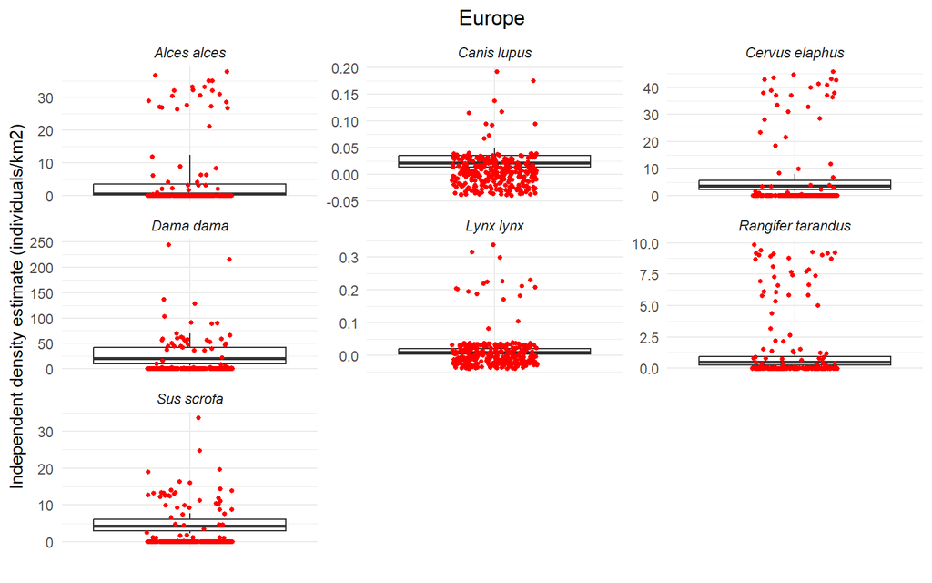

```r
# (2) independentDensity
santini2022 <- read_excel("C:/Users/User/OneDrive - Universidade de Lisboa (1)/ANDRE/SRIT_ANDRE/external_data/geb13476-sup-0002-tables1.xls") %>%
  # santini's dataframe has species names with spaces but metaRange does not like spaces
  # remove spaces again
  mutate(Species = str_replace_all(Species, " ", ""))

# validation for Boreal forests in Europe
validation_Europe <- validateModel1.2(targetspecies = c("Alcesalces", "Canislupus", "Cervuselaphus", "Damadama", "Lynxlynx", "Rangifertarandus", "Susscrofa"),
                 independentDensity = santini2022,
                 dirouts = "C:/Users/User/OneDrive - Universidade de Lisboa (1)/ANDRE/NatPoKe/trial_runs/26Mar2025_Europe/Outputs",
                 spData = read.csv(file.path("C:/Users/User/OneDrive - Universidade de Lisboa (1)/ANDRE/NatPoKe/trial_runs/26Mar2025_Europe/Inputs", "metaRangeSpeciesDataframe.csv")),
                 validationYear = 101)

europe_labels <- setNames(pretty_species_names(unique(validation_Europe$estimatedDensity$species)),
                        unique(validation_Europe$estimatedDensity$species))

europe_plot <- ggplot(validation_Europe$independentDensity, aes(x = "", y = meanDensity)) +
  geom_boxplot(aes(ymin = lw95, lower = lw75, middle = meanDensity, upper = up75, ymax = up95), stat = "identity") +
  geom_point(data = validation_Europe$estimatedDensity, aes(x = "", y = estimatedDensity), color = "red", position = position_jitter(width = 0.2), size = 1) +
  facet_wrap(~ species, scales = "free_y", labeller = labeller(species = europe_labels)) +
  ylab("Independent density estimate (individuals/km2)") +
  xlab(" ") +
  ggtitle("Europe") +
  theme_minimal() +
  theme(axis.text.x = element_blank(),
        axis.ticks.x = element_blank(),
        strip.text = element_text(face = "italic"),
        plot.title = element_text(hjust = 0.5))
europe_plot
```

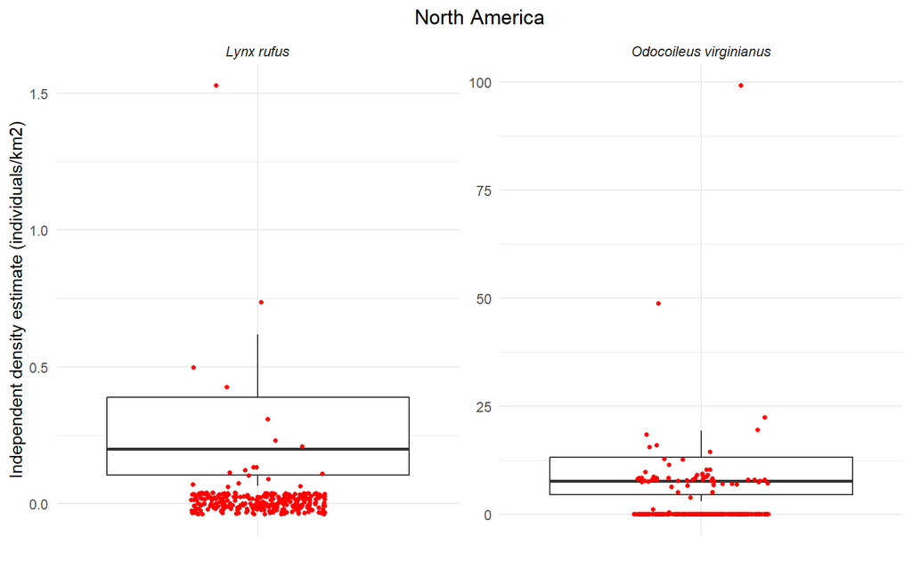

```r
# validation for boreal forests in North America
validation_NorthAmerica <- validateModel1.2(targetspecies = c("Lynxrufus", "Odocoileusvirginianus"),
                 independentDensity = santini2022,
                 dirouts = "C:/Users/User/OneDrive - Universidade de Lisboa (1)/ANDRE/NatPoKe/trial_runs/27Mar2025_NorthAmerica/Outputs",
                 spData = read.csv(file.path("C:/Users/User/OneDrive - Universidade de Lisboa (1)/ANDRE/NatPoKe/trial_runs/27Mar2025_NorthAmerica/Inputs", "metaRangeSpeciesDataframe.csv")),
                 validationYear = 101)

northamerica_labels <- setNames(pretty_species_names(unique(validation_NorthAmerica$estimatedDensity$species)),
                        unique(validation_NorthAmerica$estimatedDensity$species))

northamerica_plot <- ggplot(validation_NorthAmerica$independentDensity, aes(x = "", y = meanDensity)) +
  geom_boxplot(aes(ymin = lw95, lower = lw75, middle = meanDensity, upper = up75, ymax = up95), stat = "identity") +
  geom_point(data = validation_NorthAmerica$estimatedDensity, aes(x = "", y = estimatedDensity), color = "red", position = position_jitter(width = 0.2), size = 1) +
  facet_wrap(~ species, scales = "free_y", labeller = labeller(species = northamerica_labels)) +
  ylab("Independent density estimate (individuals/km2)") +
  xlab(" ") +
  ggtitle("North America") +
  theme_minimal() +
  theme(axis.text.x = element_blank(),
        axis.ticks.x = element_blank(),
        strip.text = element_text(face = "italic"),
        plot.title = element_text(hjust = 0.5))
northamerica_plot
```

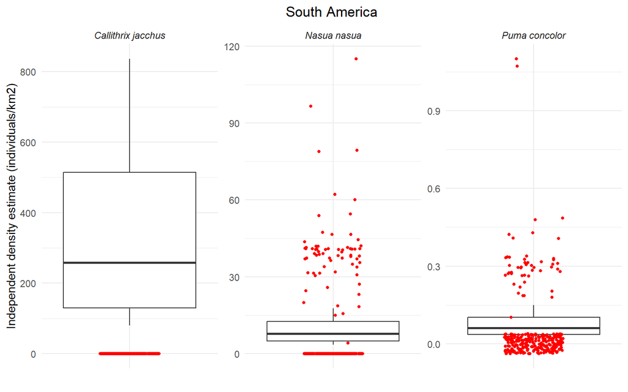

```r
# validation for Tropical forests in South Asia
validation_SouthAmerica <- validateModel1.2(targetspecies = c("Callithrixjacchus", "Nasuanasua", "Pumaconcolor"),
                 independentDensity = santini2022,
                 dirouts = "C:/Users/User/OneDrive - Universidade de Lisboa (1)/ANDRE/NatPoKe/trial_runs/27Mar2025_SouthAmerica/Outputs",
                 spData = read.csv(file.path("C:/Users/User/OneDrive - Universidade de Lisboa (1)/ANDRE/NatPoKe/trial_runs/27Mar2025_SouthAmerica/Inputs", "metaRangeSpeciesDataframe.csv")),
                 validationYear = 101)

southamerica_labels <- setNames(pretty_species_names(unique(validation_SouthAmerica$estimatedDensity$species)),
                        unique(validation_SouthAmerica$estimatedDensity$species))

southamerica_plot <- ggplot(validation_SouthAmerica$independentDensity, aes(x = "", y = meanDensity)) +
  geom_boxplot(aes(ymin = lw95, lower = lw75, middle = meanDensity, upper = up75, ymax = up95), stat = "identity") +
  geom_point(data = validation_SouthAmerica$estimatedDensity, aes(x = "", y = estimatedDensity), color = "red", position = position_jitter(width = 0.2), size = 1) +
  facet_wrap(~ species, scales = "free_y", labeller = labeller(species = southamerica_labels)) +
  ylab("Independent density estimate (individuals/km2)") +
  xlab(" ") +
  ggtitle("South America") +
  theme_minimal() +
  theme(axis.text.x = element_blank(),
        axis.ticks.x = element_blank(),
        strip.text = element_text(face = "italic"),
        plot.title = element_text(hjust = 0.5))
southamerica_plot
```

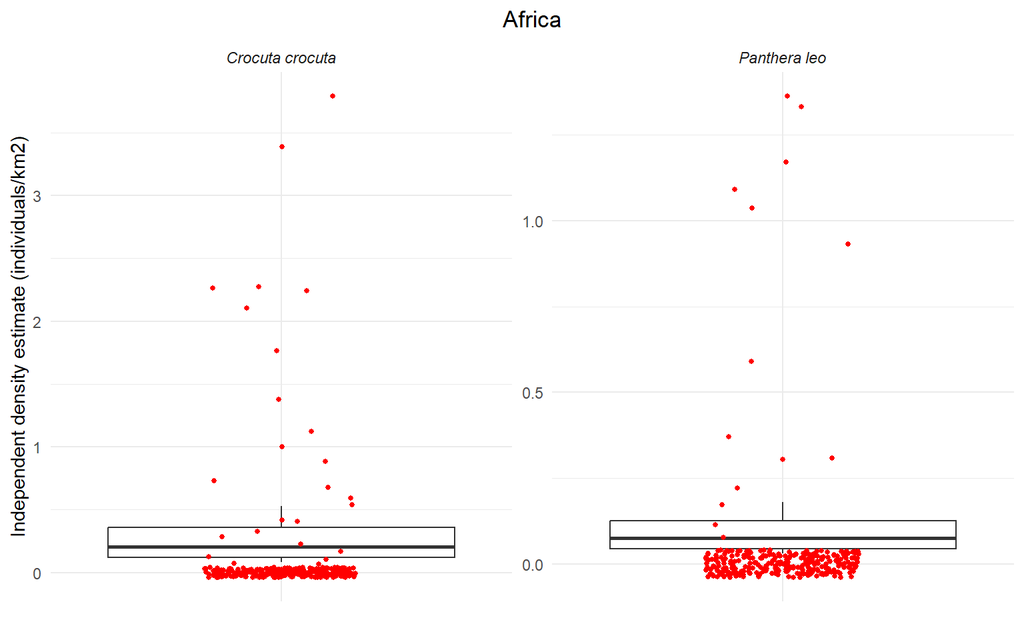

```r
# validation for Tropical forests in Africa
validation_Africa <- validateModel1.2(targetspecies = c("Crocutacrocuta", "Pantheraleo"),
                 independentDensity = santini2022,
                 dirouts = "C:/Users/User/OneDrive - Universidade de Lisboa (1)/ANDRE/NatPoKe/trial_runs/27Mar2025_Africa/Outputs",
                 spData = read.csv(file.path("C:/Users/User/OneDrive - Universidade de Lisboa (1)/ANDRE/NatPoKe/trial_runs/27Mar2025_Africa/Inputs", "metaRangeSpeciesDataframe.csv")),
                 validationYear = 101)

africa_labels <- setNames(pretty_species_names(unique(validation_Africa$estimatedDensity$species)),
                        unique(validation_Africa$estimatedDensity$species))

africa_plot <- ggplot(validation_Africa$independentDensity, aes(x = "", y = meanDensity)) +
  geom_boxplot(aes(ymin = lw95, lower = lw75, middle = meanDensity, upper = up75, ymax = up95), stat = "identity") +
  geom_point(data = validation_Africa$estimatedDensity, aes(x = "", y = estimatedDensity), color = "red", position = position_jitter(width = 0.2), size = 1) +
  facet_wrap(~ species, scales = "free_y", labeller = labeller(species = africa_labels)) +
  ylab("Independent density estimate (individuals/km2)") +
  xlab(" ") +
  ggtitle("Africa") +
  theme_minimal() +
  theme(axis.text.x = element_blank(),
        axis.ticks.x = element_blank(),
        strip.text = element_text(face = "italic"),
        plot.title = element_text(hjust = 0.5))
africa_plot
```

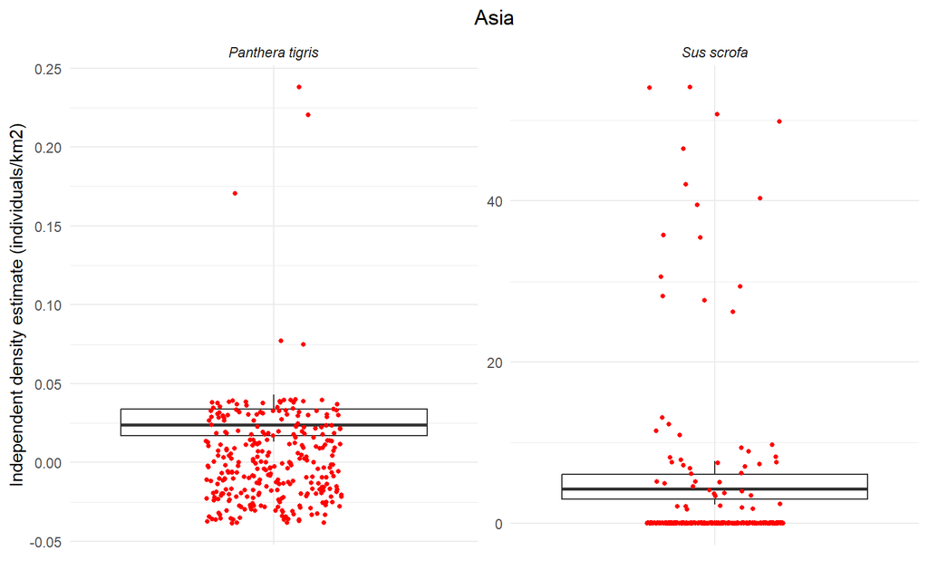

```r
# validation for Tropical forests in Asia
validation_Asia <- validateModel1.2(targetspecies = c("Pantheratigris", "Susscrofa"),
                 independentDensity = santini2022,
                 dirouts = "C:/Users/User/OneDrive - Universidade de Lisboa (1)/ANDRE/NatPoKe/trial_runs/27Mar2025_Asia/Outputs",
                 spData = read.csv(file.path("C:/Users/User/OneDrive - Universidade de Lisboa (1)/ANDRE/NatPoKe/trial_runs/27Mar2025_Asia/Inputs", "metaRangeSpeciesDataframe.csv")),
                 validationYear = 101)

asia_labels <- setNames(pretty_species_names(unique(validation_Asia$estimatedDensity$species)),
                        unique(validation_Asia$estimatedDensity$species))

asia_plot <- ggplot(validation_Asia$independentDensity, aes(x = "", y = meanDensity)) +
  geom_boxplot(aes(ymin = lw95, lower = lw75, middle = meanDensity, upper = up75, ymax = up95), stat = "identity") +
  geom_point(data = validation_Asia$estimatedDensity, aes(x = "", y = estimatedDensity), color = "red", position = position_jitter(width = 0.2), size = 1) +
  facet_wrap(~ species, scales = "free_y", labeller = labeller(species = asia_labels)) +
  ylab("Independent density estimate (individuals/km2)") +
  xlab(" ") +
  ggtitle("Asia") +
  theme_minimal() +
  theme(axis.text.x = element_blank(),
        axis.ticks.x = element_blank(),
        strip.text = element_text(face = "italic"),
        plot.title = element_text(hjust = 0.5))
asia_plot
```

# Sensitivity Analysis

If running this analysis separately from the remaining scripts make sure the right objects are set in the beginning (target_scenario, target_biome, target_region, target_species) and the directories to each run is also correctly set (baseline, and how many sensitivity runs are necessary).

1. for the **baseline data** run a for loop to build a dataframe with the abundance values of all target species per cell. Then summarise the data to be per species and produce whichever metric we are interested in, in this case the mean number of individuals per cell (the total number of individuals in the landscape is also included but not used). rename the column here to include the word “baseline”.
2. then run a user defined function to do a similar procedure to step 1 but for each sensitivity run directory, where a dataframe with the same columns as the baseline one is created per directory given. Again summarise the data to be per species and produce whichever metric we are interested in, the mean number of individuals per cell.
3. combine the two dataframes together and calculate the proportion between each sensitivity runs mean number of individuals per cell and the baseline.
4. finaly select columns and format data for plotting and plot the data in a boxplot with each species values represented as a point on top of it

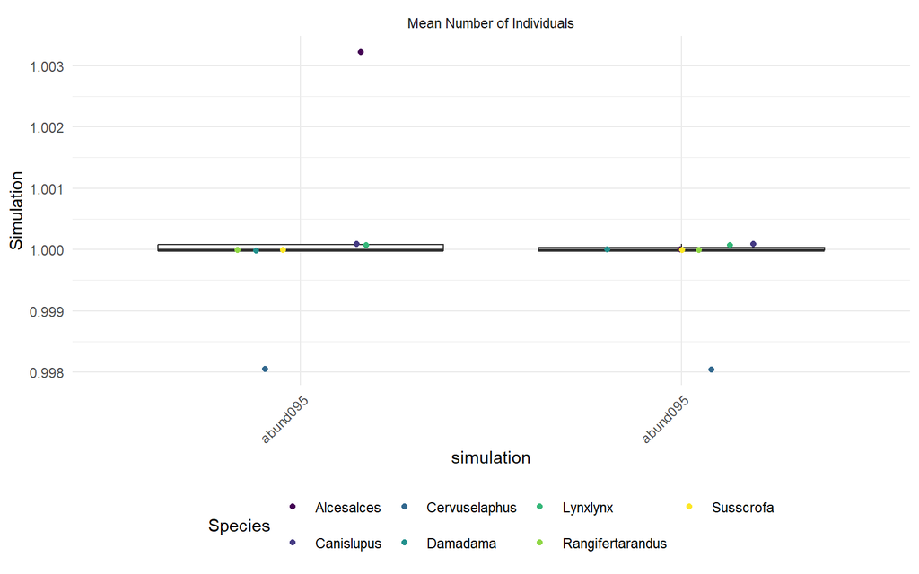